# Milestone Report for Data Science Capstone Project

Vivek Tiwari

Friday, March 18, 2016

**Note:** *I am trying to complete this course second time which I was unable to complete in previous month, hence my report is from March*

# Summary

The Capstone project for the Coursera Data Science Specialization involves using the [HC Corpora](http://www.corpora.heliohost.org/) Dataset. The Capstone project is done in collaboration with [Swiftkey](http://swiftkey.com/en/) and the goal of this project is to design a shiny application with text prediction capabilities. This report will outline the exploratory analysis of the dataset and the current plans for implementing the text prediction algorithm.

# Description of Data

The [HC Corpora](http://www.corpora.heliohost.org/) dataset is comprised of the output of crawls of news sites, blogs and twitter. A readme file with more specific details on how the data was generated can be found [here](http://www.corpora.heliohost.org/aboutcorpus.html). The dataset contains 3 files across four languages (Russian, Finnish, German and English). This project will focus on the English language datasets. The names of the data files are as follows:

1. en_US.blogs.txt
2. en_US.twitter.txt
3. en_US.news.txt

The datasets will be referred to as “Blogs”, “Twitter” and “News” for the remainder of this report.

# Download the data

```r
if(!file.exists("Coursera-SwiftKey.zip")){
    #Download the dataset
    download.file("https://d396qusza40orc.cloudfront.net/dsscapstone/dataset/Coursera-SwiftKey.zip",
                  "Coursera-SwiftKey.zip")
    Download_Date <- Sys.time()
    Download_Date
    #"2016-3-09 04:20:41 IST"

    #Unzip the dataset
    unzip("Coursera-SwiftKey.zip")
}else{
    print("Dataset is already downloaded!")
}
```

## Bugfix the News Dataset

There is a minor problem with the News dataset. This was pointed out by a previous student of the course and I have taken it into account. It contains an unusual character on line 77,259. In order to address this issue a small piece of code was written to edit out the character before processing the dataset.

```r
if(!file.exists("./final/en_US/en_US.news_edit.txt")){
    con <- file("./final/en_US/en_US.news.txt", "rb")
    News_Data <- readLines(con)
    close(con)
    #Remove the odd symbol on line 77259
    News_Data <- gsub("\032", "", News_Data, ignore.case=F, perl=T)
    writeLines(News_Data, con=file("./final/en_US/en_US.news_edit.txt"))
    close(con=file("./final/en_US/en_US.news_edit.txt"))
    file.rename("./final/en_US/en_US.news.txt", "./final/en_US.news.txt")
}else{
    con <- file("./final/en_US/en_US.news_edit.txt", "rb")
    News_Data <- readLines(con)
    close(con)
}
```

# Characteristics of Datasets

```r
#Load libraries
library(NLP)
library(tm)
library(stringi)
library(ggplot2)
library(RWeka)
library(data.table)

#Generate Corpus for text analysis
cname <- file.path(".", "final", "en_US")
docs <- Corpus(DirSource(cname))
```

The first part of this exploratory analysis is to determine the basic characteristics for each dataset. These characteristics are shown in the table below.

| Dataset | File Size (bytes) | Number of Lines | Smallest entry | Largest entry |
| --- | --- | --- | --- | --- |
| Blogs | 210160014 | 899288 | 1 | 40833 |
| Twitter | 167105338 | 2360148 | 2 | 140 |
| News | 204801643 | 1010242 | 1 | 11384 |

## Subsetting and Processing the Dataset

Each of the datasets (Blogs, Twitter and News) are large enough that processing time is a factor. In order to address this concern, a representative sampling of each of the datasets was made for the remainder of this analysis. The subset of each file is outlined in the table below.

```r
#Limit Dataset to a random subset of 20% of the data
set.seed(1337)
Subset <- docs
Subset[[1]]$content <- Subset[[1]]$content[as.logical(rbinom(length(Subset[[1]]$content),
                                                             1, prob=0.2))]
Subset[[2]]$content <- Subset[[2]]$content[as.logical(rbinom(length(Subset[[2]]$content),
                                                             1, prob=0.2))]
Subset[[3]]$content <- Subset[[3]]$content[as.logical(rbinom(length(Subset[[3]]$content),
                                                             1, prob=0.2))]
```

| Dataset | File Size (bytes) | Number of Lines | Smallest entry | Largest entry |
| --- | --- | --- | --- | --- |
| Subset Blogs | 51951080 | 179180 | 1 | 12409 |
| Subset Twitter | 63594736 | 471766 | 3 | 140 |
| Subset News | 52384464 | 202308 | 1 | 8949 |

Before the subsetted data can be fully analyzed the data needs to be pre-processed to standardize the words and characters from each dataset. An example entry from the Blogs dataset is shown below:

```
## [1] "Point 2: If it’s a show that your kid wants, a show about a book is always better than CRACCC."
```

# Word Frequency

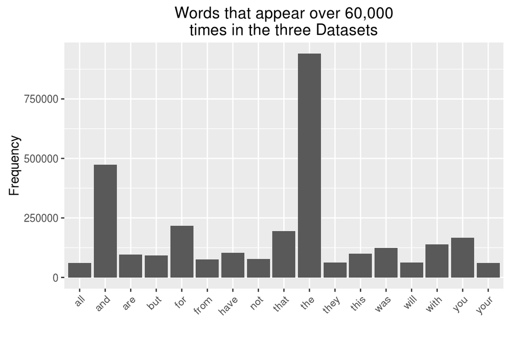

```r
#Plot Word Frequencies
ggplot(wf[wf$freq>60000, ], aes(x=word, y=freq)) +
    geom_bar(stat="identity") +
    theme(axis.text.x=element_text(angle=45, hjust=1)) +
    xlab("") +
    ylab("Frequency") +
    ggtitle("Words that appear over 60,000\ntimes in the three Datasets")
```

The high frequency for “connecting” words, such as “the”, “and”, “that” suggests that using a pattern based on word frequency alone will not be sufficient for text prediction. The next analysis looks at common word combinations.

# N-gram Frequency

For brivity the N-gram analysis of this report was limited to 2-grams.

[figure not shown]

```r
#Plot Word Frequencies
ggplot(WF_Ngram[WF_Ngram$freq>16000, ], aes(x=word, y=freq)) +
    geom_bar(stat="identity") +
    theme(axis.text.x=element_text(angle=45, hjust=1)) +
    xlab("") +
    ylab("Frequency") +
    ggtitle("Two Word Combinations (2-grams)that appear\n over 16,000 times in the three Datasets")
```

# Plan

The current plan for the development of the text prediction application will be to use the frequency of 4-grams, 3-grams and 2-grams to estimate the most likely word to follow the entered text. The trick will be to offer valid predictions of N-grams that are not observed within the dataset. In these cases the algorithm will likely default to a list of “non-common” words (i.e. factor out words like the, and, that) and estimate the best possible candidate.

# Session Information